# Applying Statistical Correction for Brain Tissue RNA Degradation to Gene Expression Differences in Schizophrenia

Amy Peterson, Andrew E Jaffe and Leonardo Collado-Torres

Johns Hopkins School of Public Health MPH  
Lieber Institute for Brain Development

andrew.jaffe@libd.org  
lcolladotor@gmail.com

18 May 2018

#### Abstract

MLR for 140.624

# 1 Introduction

This document highlights some of the multiple linear regressions that were performed for the analysis of BrainSeq data using the qSVA method to adjust for RNA-quality degradation, which confounds the signal of differential gene expression between schizophrenia cases and non-psychiatric controls in the DLPFC and HIPPO brain regions.

# 2 Load the data

First, we need to load the BrainSeq data. This includes loading the `qsvBonf`, `qSVs`, `mod`, and `modQsva` objects which were saved from a previous script but commented below. The top qSVs were obtained using Bonferroni correction on the PC’s obtained from PCA on the degradation matrix. The top k PC’s were selected using the `sva::num.sv` function (k = 16 in this case). The model saved as `mod` included diagnosis, RNA-quality, and demographic covariates. The `modQsva` object contains `mod` and the qSVs.

```r
## Load R packages required for this analysis
library('devtools')
library('SummarizedExperiment')
library('limma')
library('edgeR')
library('broom')
```

```r
#load qsvBonf, qSVs, mod, modQsva object from brainseq data
## get qSVs for top bonferroni
# qsvBonf = prcomp(t(log2(assays(cov_rse)$counts+1)))
## qsva
# k = num.sv(log2(assays(cov_rse)$counts+1), mod)
# qSVs = qsvBonf$x[,1:k]
# getPcaVars(qsvBonf)[1:k]
# # [1] 57.800 15.700  3.360  2.700  2.360  1.160  1.040  0.848  0.750  0.661
# # [11]  0.587  0.511  0.461  0.419  0.356  0.312  0.291  0.284  0.271  0.259
## modQsva = cbind(mod, qSVs)
## mod = model.matrix(~Dx + Age + Sex + mitoRate + Region + rRNA_rate +
## totalAssignedGene + RIN + snpPC1 + snpPC2 +snpPC3 + snpPC4 + snpPC5,
## data = colData(rse_gene))
#qsvBonf, qSVs, mod, modQsva were then saved in a previous script to rdas/brainseq_phase2_qsvs.Rdata
load("/dcl01/lieber/ajaffe/lab/brainseq_phase2/expr_cutoff/rse_gene.Rdata", verbose = TRUE)
```

```
## Loading objects:
##   rse_gene
```

```r
load('/dcl01/ajaffe/data/lab/qsva_brain/brainseq_phase2_qsv/rdas/brainseq_phase2_qsvs_age17_noHGold_HIPPO.Rdata', verbose = TRUE)
```

```
## Loading objects:
##   qsvBonf
##   qSVs
##   mod
##   modQsva
##   keepIndex
```

```r
## Drop prenatal
rse_gene <- rse_gene[, keepIndex]

## Keep the correct samples
keepIndex = which(rse_gene$Age>17 &
            rse_gene$Region == "HIPPO")
rse_gene <- rse_gene[, keepIndex]
mod <- mod[keepIndex, ]
modQsva <- modQsva[keepIndex, ]
```

# 3 Full qSVA analysis

As seen the overall workflow on slide 7, and slides 12 through 14 of the original presentation, below is code for the qSVA analysis that was performed using the three different models. Model 1 was a naive model that included diagnosis only. Model 2 was a model including diagnosis, and adding in RNA-quality and demographic covariates. Model 3 is a model including the qSVs, in addition to diagnosis, RNA-quality, and demographic covariates.

```r
##### GENE ######
dge = DGEList(counts = assays(rse_gene)$counts,
    genes = rowData(rse_gene))
```

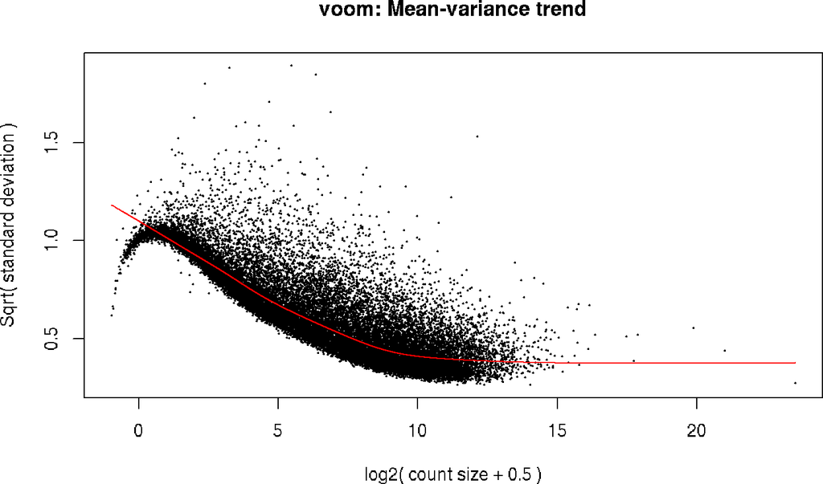

```r
#calculate library-size adjustment
dge = calcNormFactors(dge)
vGene = voom(dge,modQsva, plot=TRUE)
```

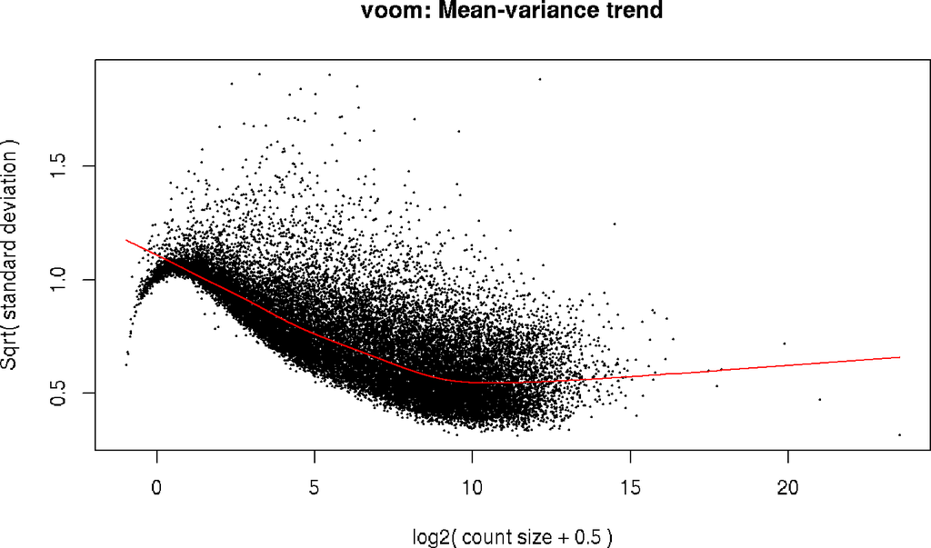

```r
fitGene = lmFit(vGene)
eBGene = eBayes(fitGene)
sigGene = topTable(eBGene,coef=2,
    p.value = 1,number=nrow(rse_gene))
outGene = sigGene[rownames(rse_gene),]

## no qSVA
vGene0 = voom(dge,mod, plot=TRUE)
```

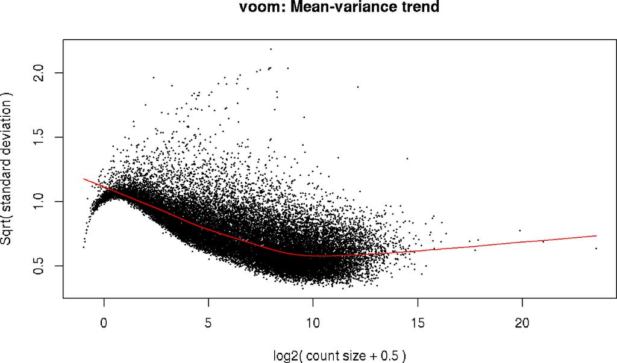

```r
fitGene0 = lmFit(vGene0)
eBGene0 = eBayes(fitGene0)
sigGene0 = topTable(eBGene0,coef=2,
    p.value = 1,number=nrow(rse_gene))
outGene0 = sigGene0[rownames(rse_gene),]

## no adjustment vars
vGeneNoAdj = voom(dge, with(colData(rse_gene), model.matrix( ~ Dx)), plot=TRUE)
```

```r
fitGeneNoAdj = lmFit(vGeneNoAdj)
eBGeneNoAdj = eBayes(fitGeneNoAdj)
sigGeneNoAdj = topTable(eBGeneNoAdj,coef=2,
    p.value = 1,number=nrow(rse_gene))
outGeneNoAdj = sigGeneNoAdj[rownames(rse_gene),]
```

# 4 Multiple linear regressions for one gene

## 4.1 `ELP6`: case where it’s not significant after qSVA

In the example gene *ELP6* seen below, the gene shown is initially seen as significant in the first two models in the HIPPO brain region. After adding in the qSVs, the gene is not seen as significant anymore. This is an example of the importance of including all of the covariates in the final model to reduce the number of false positives, or genes that are incorrectly identified as differentially expressed when in fact the perceived differential expression is a result of inadequate control of the confounding effect of RNA quality.

```r
## Find a gene that is not DE after qSVA but is in previous models
i <- which(outGene$adj.P.Val > 0.05 & outGene0$adj.P.Val < 0.05)[14]
outGene[i, ]
```

```
##                    Length          gencodeID       ensemblID      gene_type
## ENSG00000163832.15   3313 ENSG00000163832.15 ENSG00000163832 protein_coding
##                    Symbol EntrezID Class meanExprs NumTx    gencodeTx
## ENSG00000163832.15   ELP6    54859 InGen  4.082769    15 ENST0000....
##                    passExprsCut       logFC  AveExpr        t    P.Value
## ENSG00000163832.15         TRUE -0.02909726 3.142082 -1.73303 0.08408999
##                    adj.P.Val         B
## ENSG00000163832.15 0.5296745 -4.859558
```

```r
## Explore that gene in more detail
explore_gene <- function(i, expr, model = 1) {
    y <- expr$E[i, ]
    df <- as.data.frame(cbind(y, modQsva))
    if(model == 1) {
         f <- lm(y ~ DxSchizo, data = df)
    } else if (model == 2) {
         f <- lm(y ~ DxSchizo + Age + SexM + mitoRate + rRNA_rate +
                     totalAssignedGene + RIN + snpPC1 + snpPC2 +
                     snpPC3 + snpPC4 + snpPC5, data = df)
    } else if (model == 3) {
         f <- lm(y ~ DxSchizo + Age + SexM + mitoRate + rRNA_rate +
                     totalAssignedGene + RIN + snpPC1 + snpPC2 +
                     snpPC3 + snpPC4 + snpPC5 + PC1 + PC2 + PC3 +
                     PC4 + PC5 + PC6 + PC7 + PC8 + PC9 + PC10 + PC11 +
                     PC12 + PC13 + PC14 + PC15 + PC16, data = df)
    }
    summary(f)
}

## Model 1: Dx only
explore_gene(i, vGene, model = 1)
```

```
##
## Call:
## lm(formula = y ~ DxSchizo, data = df)
##
## Residuals:
##      Min       1Q   Median       3Q      Max
## -0.73648 -0.14387  0.00291  0.14168  0.57722
##
## Coefficients:
##             Estimate Std. Error t value Pr(>|t|)
## (Intercept)  3.20595    0.01549 206.966  < 2e-16 ***
## DxSchizo    -0.15990    0.02451  -6.524 2.57e-10 ***
## ---
## Signif. codes:  0 '***' 0.001 '**' 0.01 '*' 0.05 '.' 0.1 ' ' 1
##
## Residual standard error: 0.2191 on 331 degrees of freedom
## Multiple R-squared:  0.1139, Adjusted R-squared:  0.1113
## F-statistic: 42.56 on 1 and 331 DF,  p-value: 2.57e-10
```

```r
## Model 2: with all quality and demographic covariates
explore_gene(i, vGene, model = 2)
```

```
##
## Call:
## lm(formula = y ~ DxSchizo + Age + SexM + mitoRate + rRNA_rate +
##     totalAssignedGene + RIN + snpPC1 + snpPC2 + snpPC3 + snpPC4 +
##     snpPC5, data = df)
##
## Residuals:
##      Min       1Q   Median       3Q      Max
## -0.58882 -0.11890  0.01071  0.12565  0.46696
##
## Coefficients:
##                     Estimate Std. Error t value Pr(>|t|)
## (Intercept)        1.551e+00  1.698e-01   9.130  < 2e-16 ***
## DxSchizo          -9.670e-02  2.279e-02  -4.243 2.89e-05 ***
## Age               -8.480e-05  7.511e-04  -0.113 0.910184
## SexM               3.670e-03  2.212e-02   0.166 0.868345
## mitoRate          -5.459e-01  3.298e-01  -1.655 0.098893 .
## rRNA_rate          1.059e+03  4.589e+02   2.308 0.021631 *
## totalAssignedGene  2.298e+00  4.476e-01   5.135 4.92e-07 ***
## RIN                7.236e-02  1.335e-02   5.419 1.18e-07 ***
## snpPC1            -1.737e-01  2.182e-01  -0.796 0.426660
## snpPC2            -2.225e+00  2.154e+00  -1.033 0.302449
## snpPC3             3.970e+00  1.135e+00   3.497 0.000537 ***
## snpPC4             2.449e+00  6.516e+00   0.376 0.707223
## snpPC5            -2.612e+00  3.442e+00  -0.759 0.448426
## ---
## Signif. codes:  0 '***' 0.001 '**' 0.01 '*' 0.05 '.' 0.1 ' ' 1
##
## Residual standard error: 0.1806 on 320 degrees of freedom
## Multiple R-squared:  0.4177, Adjusted R-squared:  0.3958
## F-statistic: 19.13 on 12 and 320 DF,  p-value: < 2.2e-16
```

```r
## Model 3: with all of the above and the qSVs (1 to 16)
explore_gene(i, vGene, model = 3)
```

```
##
## Call:
## lm(formula = y ~ DxSchizo + Age + SexM + mitoRate + rRNA_rate +
##     totalAssignedGene + RIN + snpPC1 + snpPC2 + snpPC3 + snpPC4 +
##     snpPC5 + PC1 + PC2 + PC3 + PC4 + PC5 + PC6 + PC7 + PC8 +
##     PC9 + PC10 + PC11 + PC12 + PC13 + PC14 + PC15 + PC16, data = df)
##
## Residuals:
##      Min       1Q   Median       3Q      Max
## -0.41808 -0.07620  0.00074  0.08385  0.29247
##
## Coefficients:
##                     Estimate Std. Error t value Pr(>|t|)
## (Intercept)        3.422e+00  2.775e-01  12.332  < 2e-16 ***
## DxSchizo          -3.053e-02  1.650e-02  -1.850  0.06526 .
## Age               -3.560e-04  5.667e-04  -0.628  0.53035
## SexM              -1.723e-02  1.554e-02  -1.109  0.26843
## mitoRate           1.156e+00  4.183e-01   2.765  0.00605 **
## rRNA_rate          1.333e+02  3.797e+02   0.351  0.72567
## totalAssignedGene -1.137e+00  6.305e-01  -1.803  0.07244 .
## RIN                8.450e-03  1.266e-02   0.667  0.50511
## snpPC1             8.715e-02  1.644e-01   0.530  0.59650
## snpPC2            -5.921e-01  1.524e+00  -0.389  0.69782
## snpPC3             1.875e+00  9.368e-01   2.001  0.04625 *
## snpPC4             7.557e+00  4.561e+00   1.657  0.09854 .
## snpPC5             4.608e-01  2.399e+00   0.192  0.84778
## PC1                1.138e-02  1.398e-03   8.137 1.05e-14 ***
## PC2               -6.114e-03  1.463e-03  -4.179 3.84e-05 ***
## PC3               -2.011e-02  1.812e-03 -11.095  < 2e-16 ***
## PC4               -2.705e-03  2.389e-03  -1.132  0.25847
## PC5               -7.619e-03  3.355e-03  -2.271  0.02387 *
## PC6                9.541e-04  3.486e-03   0.274  0.78448
## PC7               -5.148e-03  3.262e-03  -1.578  0.11558
## PC8               -1.520e-03  4.136e-03  -0.368  0.71348
## PC9                6.011e-03  3.815e-03   1.576  0.11615
## PC10               1.633e-02  5.378e-03   3.036  0.00261 **
## PC11              -6.256e-03  5.390e-03  -1.161  0.24662
## PC12               4.907e-03  5.599e-03   0.876  0.38156
## PC13              -3.009e-02  5.213e-03  -5.772 1.94e-08 ***
## PC14              -1.672e-02  5.473e-03  -3.056  0.00244 **
## PC15              -2.117e-02  5.344e-03  -3.961 9.29e-05 ***
## PC16              -1.052e-02  6.123e-03  -1.718  0.08673 .
## ---
## Signif. codes:  0 '***' 0.001 '**' 0.01 '*' 0.05 '.' 0.1 ' ' 1
##
## Residual standard error: 0.1234 on 304 degrees of freedom
## Multiple R-squared:  0.7418, Adjusted R-squared:  0.718
## F-statistic: 31.19 on 28 and 304 DF,  p-value: < 2.2e-16
```

```r
## Export for editing with Excel
write.csv(tidy(explore_gene(i, vGene, model = 3)), file = 'gene1.csv')
```

## 4.2 `AHCYL1`: case where it’s significant after qSVA

In the gene *AHCYL1* below, the gene remains significant throughout the 3 different models between schizophrenia cases and non-psychiatric controls for the HIPPO brain region. This demonstrates the ability to correctly identify genes that are differentially expressed between schizophrenic cases and non-psychiatric controls. The ability to identify a gene as differentially expressed throughout all 3 models increases the confidence that the genes that are identified as differentially expressed using the final model are truly differentially expressed.

```r
## Example gene that is DE after qSVA
i <- which(outGene$adj.P.Val < 0.05)[3]
outGene[i, ]
```

```
##                    Length          gencodeID       ensemblID      gene_type
## ENSG00000168710.17   5113 ENSG00000168710.17 ENSG00000168710 protein_coding
##                    Symbol EntrezID Class meanExprs NumTx    gencodeTx
## ENSG00000168710.17 AHCYL1    10768 InGen  45.23379     6 ENST0000....
##                    passExprsCut     logFC  AveExpr        t      P.Value
## ENSG00000168710.17         TRUE 0.1196015 7.390143 4.563977 7.257743e-06
##                     adj.P.Val        B
## ENSG00000168710.17 0.01626526 3.257424
```

```r
## Model 1: Dx only
explore_gene(i, vGene, model = 1)
```

```
##
## Call:
## lm(formula = y ~ DxSchizo, data = df)
##
## Residuals:
##      Min       1Q   Median       3Q      Max
## -1.21091 -0.27162  0.00802  0.25068  1.61573
##
## Coefficients:
##             Estimate Std. Error t value Pr(>|t|)
## (Intercept)  7.34063    0.02864 256.279  < 2e-16 ***
## DxSchizo     0.12398    0.04532   2.736  0.00656 **
## ---
## Signif. codes:  0 '***' 0.001 '**' 0.01 '*' 0.05 '.' 0.1 ' ' 1
##
## Residual standard error: 0.4051 on 331 degrees of freedom
## Multiple R-squared:  0.02211,    Adjusted R-squared:  0.01915
## F-statistic: 7.483 on 1 and 331 DF,  p-value: 0.006564
```

```r
## Model 2: with all quality and demographic covariates
explore_gene(i, vGene, model = 2)
```

```
##
## Call:
## lm(formula = y ~ DxSchizo + Age + SexM + mitoRate + rRNA_rate +
##     totalAssignedGene + RIN + snpPC1 + snpPC2 + snpPC3 + snpPC4 +
##     snpPC5, data = df)
##
## Residuals:
##      Min       1Q   Median       3Q      Max
## -1.36669 -0.26087  0.00539  0.24864  1.32903
##
## Coefficients:
##                     Estimate Std. Error t value Pr(>|t|)
## (Intercept)        5.898e+00  3.659e-01  16.121  < 2e-16 ***
## DxSchizo           1.401e-01  4.909e-02   2.855  0.00459 **
## Age                4.142e-03  1.618e-03   2.560  0.01093 *
## SexM              -4.491e-02  4.765e-02  -0.942  0.34671
## mitoRate           1.735e-01  7.105e-01   0.244  0.80722
## rRNA_rate          1.543e+03  9.885e+02   1.561  0.11956
## totalAssignedGene  2.185e+00  9.642e-01   2.266  0.02410 *
## RIN                4.557e-03  2.876e-02   0.158  0.87420
## snpPC1            -7.153e-02  4.701e-01  -0.152  0.87914
## snpPC2            -1.041e+00  4.641e+00  -0.224  0.82271
## snpPC3            -3.998e+00  2.445e+00  -1.635  0.10305
## snpPC4            -1.666e+01  1.404e+01  -1.187  0.23607
## snpPC5             1.567e+00  7.413e+00   0.211  0.83275
## ---
## Signif. codes:  0 '***' 0.001 '**' 0.01 '*' 0.05 '.' 0.1 ' ' 1
##
## Residual standard error: 0.3891 on 320 degrees of freedom
## Multiple R-squared:  0.1279, Adjusted R-squared:  0.09515
## F-statistic: 3.909 on 12 and 320 DF,  p-value: 1.279e-05
```

```r
## Model 3: with all of the above and the qSVs (1 to 16)
explore_gene(i, vGene, model = 3)
```

```
##
## Call:
## lm(formula = y ~ DxSchizo + Age + SexM + mitoRate + rRNA_rate +
##     totalAssignedGene + RIN + snpPC1 + snpPC2 + snpPC3 + snpPC4 +
##     snpPC5 + PC1 + PC2 + PC3 + PC4 + PC5 + PC6 + PC7 + PC8 +
##     PC9 + PC10 + PC11 + PC12 + PC13 + PC14 + PC15 + PC16, data = df)
##
## Residuals:
##      Min       1Q   Median       3Q      Max
## -0.90810 -0.11455  0.00455  0.11754  0.66928
##
## Coefficients:
##                     Estimate Std. Error t value Pr(>|t|)
## (Intercept)        7.726e+00  4.408e-01  17.528  < 2e-16 ***
## DxSchizo           1.188e-01  2.621e-02   4.533 8.38e-06 ***
## Age                2.674e-03  9.001e-04   2.971 0.003207 **
## SexM               3.160e-02  2.468e-02   1.280 0.201419
## mitoRate           2.874e-01  6.643e-01   0.433 0.665551
## rRNA_rate         -7.429e+02  6.030e+02  -1.232 0.218925
## totalAssignedGene -3.527e-01  1.001e+00  -0.352 0.724922
## RIN               -5.098e-02  2.011e-02  -2.534 0.011764 *
## snpPC1            -4.712e-01  2.612e-01  -1.804 0.072202 .
## snpPC2             1.508e+00  2.420e+00   0.623 0.533693
## snpPC3             1.165e+00  1.488e+00   0.783 0.434364
## snpPC4             5.053e+00  7.243e+00   0.698 0.486007
## snpPC5             6.464e+00  3.810e+00   1.697 0.090799 .
## PC1                3.711e-03  2.220e-03   1.672 0.095649 .
## PC2               -3.707e-02  2.324e-03 -15.955  < 2e-16 ***
## PC3                1.161e-02  2.878e-03   4.034 6.95e-05 ***
## PC4                1.613e-02  3.794e-03   4.251 2.84e-05 ***
## PC5                3.307e-02  5.329e-03   6.206 1.78e-09 ***
## PC6                1.885e-02  5.536e-03   3.404 0.000752 ***
## PC7               -3.677e-02  5.181e-03  -7.097 9.04e-12 ***
## PC8                5.024e-02  6.568e-03   7.649 2.69e-13 ***
## PC9               -1.114e-01  6.059e-03 -18.382  < 2e-16 ***
## PC10               3.449e-02  8.541e-03   4.038 6.82e-05 ***
## PC11              -8.359e-04  8.560e-03  -0.098 0.922271
## PC12               3.693e-02  8.893e-03   4.152 4.28e-05 ***
## PC13               4.191e-02  8.280e-03   5.062 7.21e-07 ***
## PC14              -1.993e-02  8.692e-03  -2.293 0.022546 *
## PC15               7.445e-03  8.487e-03   0.877 0.381053
## PC16               1.925e-02  9.725e-03   1.979 0.048678 *
## ---
## Signif. codes:  0 '***' 0.001 '**' 0.01 '*' 0.05 '.' 0.1 ' ' 1
##
## Residual standard error: 0.196 on 304 degrees of freedom
## Multiple R-squared:  0.7897, Adjusted R-squared:  0.7704
## F-statistic: 40.78 on 28 and 304 DF,  p-value: < 2.2e-16
```

```r
## Export for editing with Excel
write.csv(tidy(explore_gene(i, vGene, model = 3)), file = 'gene2.csv')
```

## 4.3 Adjusted covariates interpretation

For *ELP6*, the false positive example that appeared to be differentially expressed until the qSVs were added in for Model 3. In Model 2, where *ELP6* still appears to be differentially expressed, RIN is statistically significant (p=1.18x10-7). In Model 3, where *ELP6* is no longer differentially expressed, RIN is not statistically significant (p=0.50511).

# 5 Conclusions

The MLR analysis shown for the two example genes was completed for all of the aproximately 25,000 genes contained in the BrainSeq dataset, a case-control dataset comparing schizophrenic cases to non-psychiatric controls. In the examples shown, *ELP6* was a false positive gene incorrectly identified as differentially expressed between the two groups until the qSVs were added, and *AHCLY1* was a gene that remained differentially expressed throughout all 3 models. The ability to correctly identify the genes in the dataset as differentially expressed between the two groups was dependent on adequate control of RNA quality confounding. The effectiveness of the statistical correction for RNA quality confounding was shown by the DEqual plots displayed on slides 12 - 14.

Overall, the qSVA method greatly reduced the number of differentially expressed genes between schizophrenia cases and non-psychiatric controls, thus increasing the confidence in the results.

# Session info

This section shows the R session information for reproducing the analysis. This document was generated using the JHPCE computing cluster due to the size of the data analyzed.

[session information not shown]

```
##  setting  value
##  version  R version 3.5.0 Patched (2018-04-30 r74679)
##  system   x86_64, linux-gnu
##  ui       X11
##  language (EN)
##  collate  en_US.UTF-8
##  tz       US/Eastern
##  date     2018-05-18
```

```
## Packages --------------------------------------------------------------------------------------------------------------
```

```
##  package              * version   date       source
##  assertthat             0.2.0     2017-04-11 CRAN (R 3.5.0)
##  backports              1.1.2     2017-12-13 CRAN (R 3.5.0)
##  base                 * 3.5.0     2018-05-02 local
##  bindr                  0.1.1     2018-03-13 CRAN (R 3.5.0)
##  bindrcpp               0.2.2     2018-03-29 CRAN (R 3.5.0)
##  Biobase              * 2.40.0    2018-05-02 Bioconductor
##  BiocGenerics         * 0.26.0    2018-05-03 Bioconductor
##  BiocParallel         * 1.14.1    2018-05-17 Bioconductor
##  BiocStyle            * 2.8.1     2018-05-17 Bioconductor
##  bitops                 1.0-6     2013-08-17 CRAN (R 3.5.0)
##  bookdown               0.7       2018-02-18 CRAN (R 3.5.0)
##  broom                * 0.4.4     2018-03-29 CRAN (R 3.5.0)
##  compiler               3.5.0     2018-05-02 local
##  datasets             * 3.5.0     2018-05-02 local
##  DelayedArray         * 0.6.0     2018-05-02 Bioconductor
##  devtools             * 1.13.5    2018-02-18 CRAN (R 3.5.0)
##  digest                 0.6.15    2018-01-28 CRAN (R 3.5.0)
##  dplyr                  0.7.4     2017-09-28 CRAN (R 3.5.0)
##  edgeR                * 3.22.1    2018-05-17 Bioconductor
##  evaluate               0.10.1    2017-06-24 CRAN (R 3.5.0)
##  foreign                0.8-70    2017-11-28 CRAN (R 3.5.0)
##  GenomeInfoDb         * 1.16.0    2018-05-03 Bioconductor
##  GenomeInfoDbData       1.1.0     2018-04-17 Bioconductor
##  GenomicRanges        * 1.32.3    2018-05-17 Bioconductor
##  glue                   1.2.0     2017-10-29 CRAN (R 3.5.0)
##  graphics             * 3.5.0     2018-05-02 local
##  grDevices            * 3.5.0     2018-05-02 local
##  grid                   3.5.0     2018-05-02 local
##  htmltools              0.3.6     2017-04-28 CRAN (R 3.5.0)
##  IRanges              * 2.14.10   2018-05-17 Bioconductor
##  knitr                  1.20      2018-02-20 CRAN (R 3.5.0)
##  lattice                0.20-35   2017-03-25 CRAN (R 3.5.0)
##  limma                * 3.36.1    2018-05-17 Bioconductor
##  locfit                 1.5-9.1   2013-04-20 CRAN (R 3.5.0)
##  magrittr               1.5       2014-11-22 CRAN (R 3.5.0)
##  Matrix                 1.2-14    2018-04-13 CRAN (R 3.5.0)
##  matrixStats          * 0.53.1    2018-02-11 CRAN (R 3.5.0)
##  memoise                1.1.0     2017-04-21 CRAN (R 3.5.0)
##  methods              * 3.5.0     2018-05-02 local
```

[output cut: 15 more lines]

```
##  S4Vectors            * 0.18.2    2018-05-17 Bioconductor
##  stats                * 3.5.0     2018-05-02 local
##  stats4               * 3.5.0     2018-05-02 local
##  stringi                1.2.2     2018-05-02 CRAN (R 3.5.0)
##  stringr                1.3.1     2018-05-10 CRAN (R 3.5.0)
##  SummarizedExperiment * 1.10.1    2018-05-17 Bioconductor
##  tibble                 1.4.2     2018-01-22 CRAN (R 3.5.0)
##  tidyr                  0.8.0     2018-01-29 CRAN (R 3.5.0)
##  tools                  3.5.0     2018-05-02 local
##  utils                * 3.5.0     2018-05-02 local
##  withr                  2.1.2     2018-03-15 CRAN (R 3.5.0)
##  xfun                   0.1       2018-01-22 CRAN (R 3.5.0)
##  XVector                0.20.0    2018-05-03 Bioconductor
##  yaml                   2.1.19    2018-05-01 CRAN (R 3.5.0)
##  zlibbioc               1.26.0    2018-05-02 Bioconductor
```